# Identifying whole-blood gene expression after IV BCG in NHP that is associated with protection from Mtb challenge

## Data

This TB Hackday script uses (pre-processed) RNA sequencing data from the following study:

1. [Liu et al. 2023](https://pubmed.ncbi.nlm.nih.gov/37390827/) (*Cell Rep Med*) **Blood transcriptional correlates of BCG-induced protection against tuberculosis in rhesus macaques**

The animals in that study were also the animals in these two related studies:

1. [Darrah et al. 2023](https://pubmed.ncbi.nlm.nih.gov/37267955/) (Cell Host Microbe) **Airway T cells are a correlate of i.v. Bacille Calmette-Guerin-mediated protection against tuberculosis in rhesus macaques**
2. [Darrah et al. 2020](https://pubmed.ncbi.nlm.nih.gov/31894150/) (*Nature*) **Prevention of tuberculosis in macaques after intravenous BCG immunization**

## Background

In the earlier “route” study Darrah et al. (2020) immunized NHP with BCG by varying routes. After 24 weeks the animals were challenged in the lung with Mycobacterium tuberculosis (Mtb). In a follow-up IV BCG “dose” study Darrah et al. (2023) immunized 34 NHP with various doses of intravenously (i.v.) BCG. Again the animals were challenged after 24 weeks with Mtb. The Liu et al. study conducted whole-blood RNA sequencing on samples from NHP in both the Darrah et al. studies.

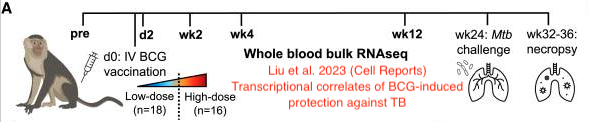

Liu et al. 2023 Cell Reports Time Points

## Hypotheses for hacking

- The original manuscript first identified genes that were differentially up-regulated after BCG and then looked for association with protection. Can we directly identify genes that are associated with protection? Does the model need adjustment for covariates? e.g., sex, route, dose
- Can we use clustering/WGCNA to identify gene modules or GSEA to identify pre-existing gene modules associated with protection?
- How well do the genes classify protected and non-protected animals using CV-AUC?
- Does baseline expression of the BCG-responsive genes associate with protection?

## Setup R and load the data.

Load relevant packages. Change `<data_dir>` variable as appropriate.

Load the pre-processed RNA sequencing data. There are two important files:

1. `liu_et_al_counts.csv` contains normalized counts that were computed from raw counts by the study authors using DESEQ2 variance stabilizing transform (`vst`). The table contains 312 columns, with one column `gene` and the remaining columns matching `sampleid`s in the metadata. There are 22,496 genes in the dataset.
2. `liu_etal_meta.csv` contains all the 29 sample-level metadata that is available for these samples and animals including `sampleid`, `studyid`, `animalid`, `visit`, `route`, `dose_group`, `log_mtb_cfu`, and `protect_outcome`.

```r
library(tidyverse)
library(edgeR)
library(limma)
library(kimma)
library(ggrepel)
library(BIGpicture)

# NOTE --- REPLACE the <data_dir> FOLDER DESTINTATION AS APPROPRIATE
# data_dir <- '/fh/fast/gilbert_p/fg_data/SEATRAC/TB_hackday_2024/processed_data'
# data_dir <- '/home/processed_data'
data_dir <- 'data'

ncts <- readr::read_csv(file.path(data_dir, "liu_etal_counts.csv"))
meta <- readr::read_csv(file.path(data_dir, "liu_etal_metadata.csv"))
```

## Prepare the data for differential gene expression analysis with Voom

The `sampleid` columns of the `ncts` variable and the rows of `sampleid` in the `meta` variable match. For this first analysis we will focus on the NHP that received high-dose IV BCG and the blood from 2 weeks after immunization, creating subset tables indicated by `_ss` variables. Then we initialize the `DGEList` object and create a `limma` `voom` model with a design matrix to identify genes that are associated with protection.

Notice also that we specify a design matrix which includes covariates `sexM` (male = 1)

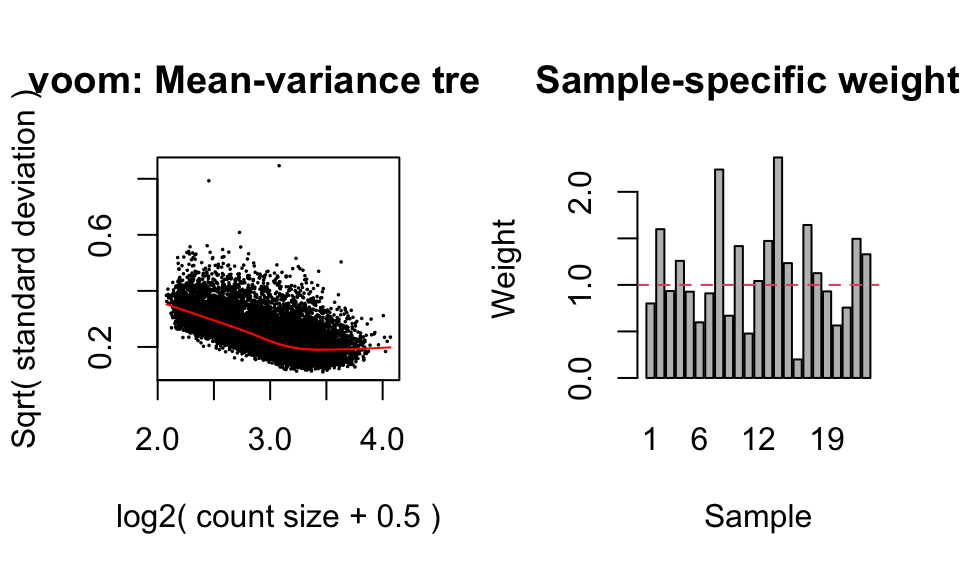

```r
# Focus initial analysis on high-dose IV BCG group and the pre-vaccine (week 2) time point
meta_ss = meta %>% filter(vax_group == "IV-HD" & visit == "wk2")
keep_ids = meta_ss %>% pull(sampleid)
keep_ids = c('gene', keep_ids)

ncts_ss = ncts %>% dplyr::select(any_of(keep_ids))

# Discard genes that have low counts/prevalence
## Keep genes expressed at > 1 normalized count in at least 50% of samples
filter = rowSums(ncts_ss > 1) >= (0.5 * ncol(ncts_ss))
ncts_ss = ncts_ss[filter, ]

# Move gene ID to rownames
ncts_ss_mat <- as.matrix(ncts_ss[,-1])
rownames(ncts_ss_mat) = ncts_ss$gene

# Create the object for differential expression testing
dge_o = DGEList(counts=ncts_ss_mat,
                genes=rownames(ncts_ss_mat),
                samples=meta_ss,
                group=meta_ss[['protect_outcome']])

## Trimmed mean of means normalize
## We skip this step because counts were previously normalized by VST. If you were working with raw counts, this would need to be completed
# dge_o <- calcNormFactors(dge_o, method=c("TMM"))

# Specify the model/design matrix
design_temp = model.matrix(~protect_outcome + sex, data=dge_o$samples)

# Create the voom object and fit the model
v <- voomWithQualityWeights(dge_o, design=design_temp, plot=TRUE)
```

### Exercise

Re-run the code block above without the filtering to see the impact on the mean-variance plot. Use the code above but comment out lines `filter = rowSums(ncts_ss > 1) >= (0.5 * ncol(ncts_ss))` and `ncts_ss = ncts_ss[filter, ]`. How does this effect the mean variance plot? **Make sure to rerun the code correctly before continuing to the next section so the object `v` includes filtering sparsely detected genes.*

## Fit the model to identify genes associated with protection

```r
fit = lmFit(v, design_temp)

# Estimate contrasts and p-values
fit = eBayes(fit, robust=TRUE)

summary(decideTests(fit, adjust.method="fdr", p.value = 0.2))
```

```
       (Intercept) protect_outcomeprotected  sexM
Down             0                        2    18
NotSig           0                    12605 12568
Up           12608                        1    22
```

```r
results <- topTable(fit, adjust="BH", coef="protect_outcomeprotected", p.value=1, number=Inf, resort.by="P")

head(results %>% dplyr::select(genes, logFC, AveExpr, P.Value, adj.P.Val), 20)
```

```
                                genes       logFC  AveExpr      P.Value
SLC1A6                         SLC1A6 -0.34166124 5.598826 2.083323e-05
BTBD19                         BTBD19  0.18060254 5.827599 2.308577e-05
DDX31                           DDX31 -0.07084389 6.270161 2.540100e-05
UTP25                           UTP25 -0.06548461 6.354840 1.425641e-04
CHST10                         CHST10 -0.09289009 6.226276 1.755175e-04
PARP11                         PARP11 -0.06232913 6.389205 2.089512e-04
ENSMMUG00000051066 ENSMMUG00000051066 -0.38439801 5.553205 2.267430e-04
PSMG4                           PSMG4 -0.10101247 6.351959 2.307531e-04
LMF1                             LMF1  0.09704271 6.469537 3.301356e-04
CAMSAP2                       CAMSAP2 -0.11780622 5.986679 3.322245e-04
UNC5B                           UNC5B -0.11318311 6.019161 4.227846e-04
AKAP6                           AKAP6 -0.18957999 5.549775 5.485808e-04
CLEC1B                         CLEC1B  0.22628843 5.966358 5.689664e-04
KLHL8                           KLHL8 -0.06065326 6.288133 5.701723e-04
IGKV6D-41                   IGKV6D-41 -0.17524777 5.627697 5.746743e-04
PDE9A                           PDE9A -0.12837626 5.960126 6.447862e-04
SPATC1                         SPATC1 -0.18963455 5.835173 6.833852e-04
ICE1                             ICE1 -0.04691637 6.679648 7.130011e-04
CARMIL1                       CARMIL1 -0.09739404 6.056295 7.832276e-04
CEP57L1                       CEP57L1 -0.10845601 6.062446 8.038791e-04
                   adj.P.Val
SLC1A6             0.1067519
BTBD19             0.1067519
DDX31              0.1067519
UTP25              0.3636668
CHST10             0.3636668
PARP11             0.3636668
ENSMMUG00000051066 0.3636668
PSMG4              0.3636668
LMF1               0.4188686
CAMSAP2            0.4188686
UNC5B              0.4818768
AKAP6              0.4818768
CLEC1B             0.4818768
KLHL8              0.4818768
IGKV6D-41          0.4818768
PDE9A              0.4818768
SPATC1             0.4818768
ICE1               0.4818768
CARMIL1            0.4818768
CEP57L1            0.4818768
```

## Create a volcano plot for single-gene association with protection

A volcano plot shows log fold-change on the x-axis and negative log10-transformed p-value on the y-axis. Each dot represents a gene. In this case fold change is based on grouping variable of `protection_outcome` protected and un-protected, with points the right enriched in animals with protected status, after adjusting for the sex variable.

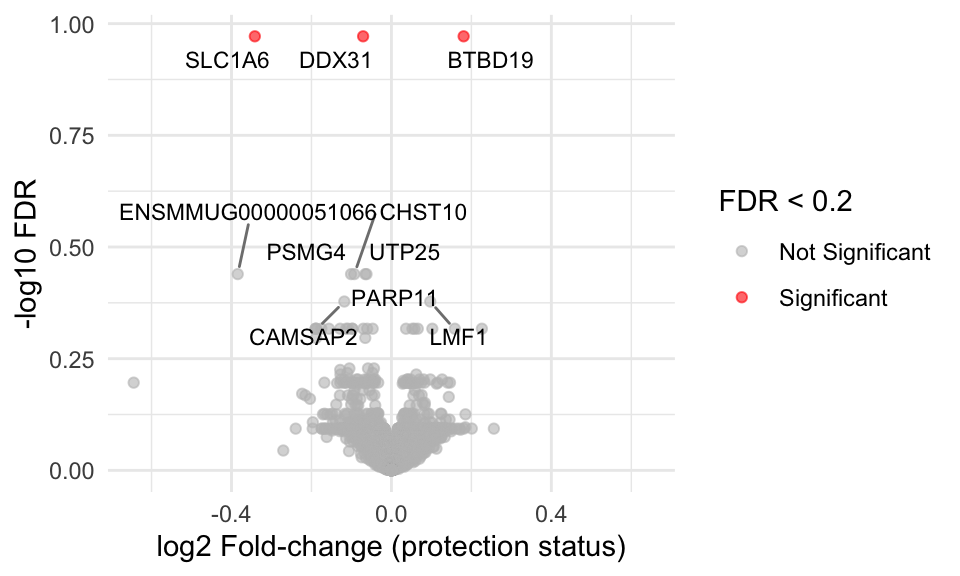

```r
# Add a column for significance based on FDR
results <- results %>%
  mutate(Significance = ifelse(adj.P.Val < 0.2, "Significant", "Not Significant"))

# Select the top 10 genes based on adjusted p-value for labeling
top_genes <- results %>%
  arrange(adj.P.Val) %>%
  slice_head(n = 10)

max_logFC <- max(abs(results$logFC), na.rm = TRUE)

# Create the volcano plot
volcano_plot <- ggplot(results, aes(x = logFC, y = -log10(adj.P.Val))) +
  geom_point(aes(color = Significance), alpha = 0.6) +
  scale_color_manual(values = c("Significant" = "red", "Not Significant" = "grey")) +
  geom_text_repel(data = top_genes,
                  aes(label = genes),
                  max.overlaps = Inf,
                  box.padding = 0.3,
                  point.padding = 0.3,
                  segment.color = "grey50",
                  size = 3) +
  xlim(c(-max_logFC, max_logFC)) +
  theme_minimal() +
  labs(
       x = "log2 Fold-change (protection status)",
       y = "-log10 FDR",
       color = "FDR < 0.2") +
  theme(plot.title = element_text(hjust = 0.5))
volcano_plot
```

## See if there are any genes significantly associated with sex of the animals

In the prior model, we see some differences by sex.

```r
summary(decideTests(fit, adjust.method="fdr", p.value = 0.2))
```

```
       (Intercept) protect_outcomeprotected  sexM
Down             0                        2    18
NotSig           0                    12605 12568
Up           12608                        1    22
```

See if you can modify the code from above (copied below) to test for differentially expressed genes in the male animals. Change the `coef` argument in `topTable` function.

```r
#Use the same voom object and model fit

results <- topTable(fit, adjust="BH", coef="sexM", p.value=1, number=Inf, resort.by="P")

head(results %>% dplyr::select(genes, logFC, AveExpr, P.Value, adj.P.Val), 20)
```

```
                                genes       logFC  AveExpr      P.Value
KDM5D                           KDM5D  1.26898903 5.921612 3.393046e-26
USP9Y                           USP9Y  0.99799688 6.162297 1.334377e-25
RPS4Y1                         RPS4Y1  1.33905682 6.319479 2.630139e-25
UTY                               UTY  1.23691737 5.907697 7.362728e-24
DDX3Y                           DDX3Y  1.37068609 6.062527 3.444812e-23
RPS4Y2                         RPS4Y2  1.12576863 6.068310 8.801850e-23
ZFY                               ZFY  1.04555466 5.969083 5.148318e-21
CYorf15A                     CYorf15A  1.02525700 5.789767 2.877145e-19
ENSMMUG00000056331 ENSMMUG00000056331  0.60981483 6.179036 9.319909e-17
TBL1Y                           TBL1Y  0.63894564 5.766605 2.967334e-15
EIF1AY                         EIF1AY  0.55804082 5.961327 2.383709e-13
KDM6A                           KDM6A -0.11255159 6.621208 3.151353e-10
EIF1AX                         EIF1AX -0.09897533 6.635283 4.311215e-10
ZFX                               ZFX -0.09326872 6.602602 5.546894e-09
MAP7D2                         MAP7D2 -0.27819120 5.736375 1.255268e-08
PRKX                             PRKX -0.10521002 6.741735 2.460200e-08
KDM5C                           KDM5C -0.06806238 6.862558 7.563125e-08
SYAP1                           SYAP1 -0.08055528 6.487668 3.821820e-07
TXLNG                           TXLNG -0.12491528 6.298410 3.994882e-07
CXHXorf38                   CXHXorf38 -0.06360513 6.681437 1.259831e-06
                      adj.P.Val
KDM5D              4.277952e-22
USP9Y              8.411914e-22
RPS4Y1             1.105360e-21
UTY                2.320732e-20
DDX3Y              8.686438e-20
RPS4Y2             1.849562e-19
ZFY                9.272857e-18
CYorf15A           4.534381e-16
ENSMMUG00000056331 1.305616e-13
TBL1Y              3.741215e-12
EIF1AY             2.732164e-10
KDM6A              3.311021e-07
EIF1AX             4.181215e-07
ZFX                4.995374e-06
MAP7D2             1.055094e-05
PRKX               1.938638e-05
KDM5C              5.609169e-05
SYAP1              2.650920e-04
TXLNG              2.650920e-04
CXHXorf38          7.941972e-04
```

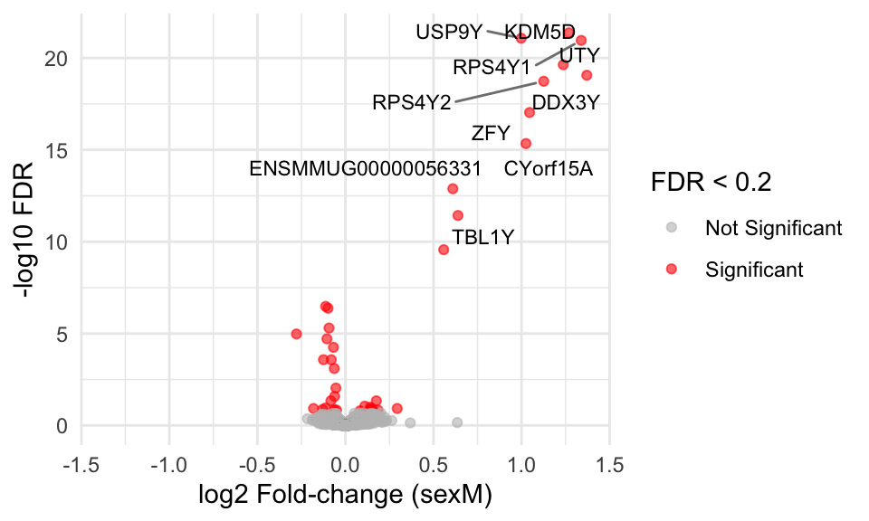

```r
# Add a column for significance based on FDR
results <- results %>%
  mutate(Significance = ifelse(adj.P.Val < 0.2, "Significant", "Not Significant"))

# Select the top 10 genes based on adjusted p-value for labeling
top_genes <- results %>%
  arrange(adj.P.Val) %>%
  slice_head(n = 10)

max_logFC <- max(abs(results$logFC), na.rm = TRUE)

# Create the volcano plot
volcano_plot <- ggplot(results, aes(x = logFC, y = -log10(adj.P.Val))) +
  geom_point(aes(color = Significance), alpha = 0.6) +
  scale_color_manual(values = c("Significant" = "red", "Not Significant" = "grey")) +
  geom_text_repel(data = top_genes,
                  aes(label = genes),
                  max.overlaps = Inf,
                  box.padding = 0.3,
                  point.padding = 0.3,
                  segment.color = "grey50",
                  size = 3) +
  xlim(c(-max_logFC, max_logFC)) +
  theme_minimal() +
  labs(
       x = "log2 Fold-change (sexM)",
       y = "-log10 FDR",
       color = "FDR < 0.2") +
  theme(plot.title = element_text(hjust = 0.5))
volcano_plot
```

## Redo the analysis using a mixed-effects model to incorporate data from additional visits and account for the longitudinal design

First, make a new voom object with two time points (day 2 and week 2).

```r
meta_ss = meta %>% filter(vax_group == "IV-HD" & (visit == "wk2" | visit == "d2"))
keep_ids = meta_ss %>% pull(sampleid)
keep_ids = c('gene', keep_ids)

ncts_ss = ncts %>% dplyr::select(any_of(keep_ids))

# Discard genes that have low counts/prevalence
## Keep genes expressed at > 1 normalized count in at least 50% of samples
filter = rowSums(ncts_ss > 1) >= (0.5 * ncol(ncts_ss))
ncts_ss = ncts_ss[filter, ]

# Move gene ID to rownames
ncts_ss_mat <- as.matrix(ncts_ss[,-1])
rownames(ncts_ss_mat) = ncts_ss$gene

dge_o = DGEList(counts=ncts_ss_mat,
                genes=rownames(ncts_ss_mat),
                samples=meta_ss,
                group=meta_ss[['protect_outcome']])

## We skip this step because counts were previously normalized by VST. If you were working with raw counts, this would need to be completed
# dge_o <- calcNormFactors(dge_o, method=c("TMM"))

design_temp=model.matrix(~protect_outcome + visit + sex, data=dge_o$samples)

v <- voomWithQualityWeights(dge_o, design=design_temp, plot=FALSE)
```

Then use kimma to fit a mixed effects model.

```r
klm <- kmFit(
  dat = v,
  model = "~protect_outcome + visit + sex + (1|animalid)",
  run_lme = TRUE,
  run_contrast = FALSE,
  libraryID="sampleid",
  patientID="animalid",
  use_weights = TRUE,
  metrics = FALSE,
  processors=6)
```

```
lme/lmerel model: expression~protect_outcome+visit+sex+(1|animalid)
```

```
Input: 45 libraries from 23 unique patients
```

```
Model: 45 libraries
```

```
Complete: 12608 genes
```

```
Failed: 0 genes
```

```r
summarise_kmFit(fdr = klm$lm)
```

```
# A tibble: 5 × 7
  variable          `fdr<0.05` `fdr<0.1` `fdr<0.2` `fdr<0.3` `fdr<0.4` `fdr<0.5`
  <fct>                  <int>     <int>     <int>     <int>     <int>     <int>
1 (1 | animalid)          4548      6110      7826      8849      9566     10118
2 protect_outcome            9        10        41       114       209       433
3 sex                       41        54       108       192       368       617
4 visit                   7076      7815      8737      9364      9937     10411
5 total (nonredund…       9100     10177     11179     11708     12029     12247
```

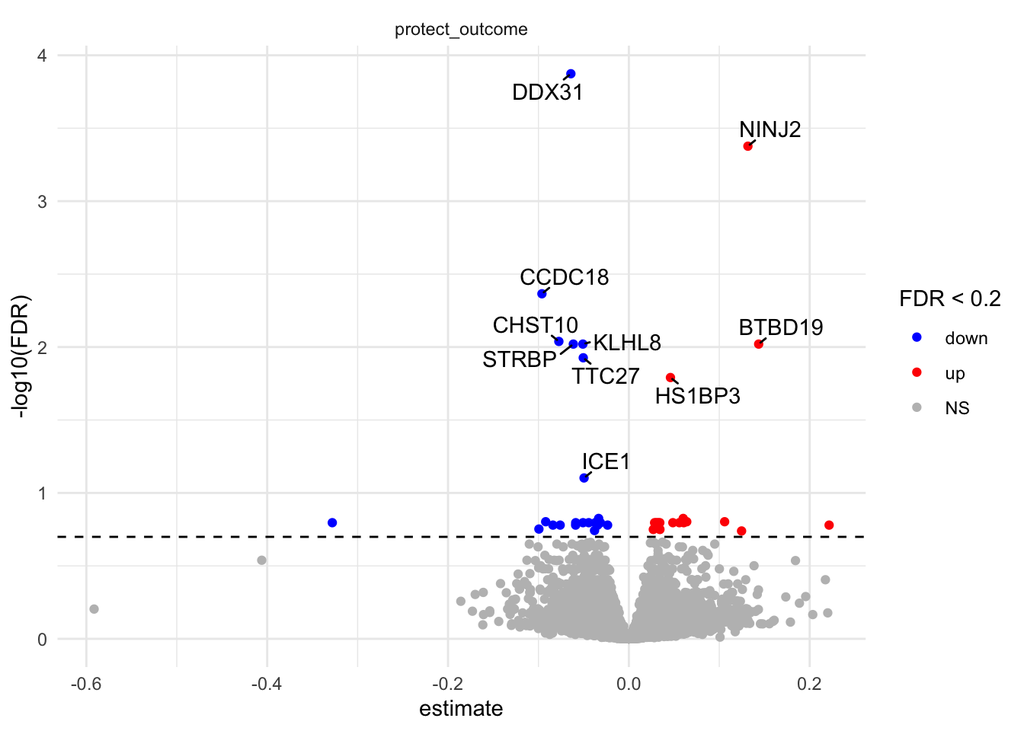

```r
# BIGpicture has a nice wrapper for volcano plots
plot_volcano(model_result = klm,
             model = "lme", variables = "protect_outcome",
             y_cutoff = 0.2, label = 10)
```

If you want to delve deeper into the pairwise comparisons within the interaction term (e.g. what is the effect time in each protection outcome?), try running kimma contrasts and exploring the output `klm$lme.contrast`.

```r
klm <- kmFit(
  dat = v,
  model = "~protect_outcome*visit + sex + (1|animalid)", #Include interaction
  run_lme = TRUE,
  run_contrast = TRUE, contrast_var="protect_outcome:visit", #Run contrasts
  libraryID="sampleid",
  patientID="animalid",
  use_weights = TRUE,
  metrics = FALSE,
  processors=6)
```